# **Safe n’ Sound**

Suraj Gangaram (_sgang624@uw.edu), Sumaya Mohamud (smoham2@uw.edu), Victoria Mulugeta (vmulu1@uw.edu), Duy Nguyen (dnh7@uw.edu), Mike Ramsay (mramsay2@uw.edu)

Winter 2022

## **Abstract**

**Our main question** is regarding *neighborhood safety* and how much of a factor *socioeconomic status* has on the **safety within a neighborhood**. **This question is of importance** because many communities do not have the proper representation and police protection, they are adversely affected by crime and city negligence as a result. **To address the question**, we will analyze datasets of crime rates in both higher and lower income neighborhoods in order to determine any associations between a neighborhood’s socioeconomic status and level of crime (measured in rates).

## **Keywords:**

Crime, Safety, Low-Income, Neighborhood, Economic-Differences.

## **Introduction**

The project we are hoping to construct with our topic of neighborhood safety, is bringing attention to the **lack** of safety in lower-income neighborhoods. Through *analyzing* different neighborhoods crime and safety data in relation to the socioeconomic incomes of the families in those neighborhoods we hope to raise attention to the discrepancies between the amount of police and crime protection low income neighborhoods receive in comparison to higher income neighborhoods. With the results gathered from this project, we hope to provide useful insight for those representing lower income neighborhoods and incentive to bring about change, through implementing new legislation and bills to ensure that those with low incomes feel safe and are protected from crimes within their neighborhoods. Additionally, we hope that this project will spark interest in others to also research the differences in crime and protection and continue to provide more data to implement changes to address these inequities.

## **Design Situation**

### Project-Framing:

The **goal** of this project is to study the *connection* between the income level in different areas and the different types of crime rates in those areas. By doing this, we are trying to bring attention to **the safety and equity issues** in low-income neighborhoods. A similar project found that for poor income households, the rate of nonfatal violent victimization doubled compared to high-income households[^1]. We **hope** this project and others like it can become useful data for activists, journalists, politicians, or anyone trying to bring forth equity and safety to the marginalized and minoritized communities in America.

### Human-Values:

The two human-values in our topic are **Equity** and **Safety**. **Equity** is the value of *fair treatment and justice among all people*. In this value, it must be **acknowledged** not all people have access to equal resources and opportunities, and we must work together to eliminate inequalities and bring everyone to the same level of equality. This leads to **Safety** as a value. As humans, we all want to be safe. Having equity for everyone leads to the safety of all people as motivations for committing crimes gets eliminated[^2].

### Direct Stakeholders:

Some of the direct stakeholders are **low-income community leaders, researchers, journalists, students, and activists**. These individuals are those who will be directly advocating and reporting these inequalities present in the data. Whether they will bring good or harm to these low-income communities will *depend* on the stakeholders and the values they hold. Still, the ability to understand statistical analysis is required to effectively utilize this project.

### Indirect Stakeholders:

Some of the indirect stakeholders are city council members, state representatives, and news readers/watchers. They are the people that arguments, bills, and legislatures constructed from this project are being presented to. They are people that hold power in making decisions that can make the world more equitable and safer for minoritized and marginalized groups.

### Benefits:

The benefit of this project is highlight issues of safety and crimes affecting low-income areas. From this, bills, legislatures, and arguments can be constructed to bring forth **a more equitable and safer place for everyone**. By doing this project, **hopefully** it will inspire others to do similar projects.

### Harms:

Potential harms from this project is the potential of **redlining** in low-income neighborhoods due to the publication of this project. By publicly displaying information about crime rates of neighborhoods, **social stigma(s)** could be formed around different neighborhoods, thus **negatively** affecting the lives of people living in those communities[^3]. This could lead to reduced sales for business as they see less people coming to them or redlining from banks for people in the neighborhood.

## **Research Questions**

- How much of an issue is neighborhood safety in low income areas?
- What type of crimes are likely to occur in low-income areas?
- What is the difference between crime rates in low-income and high-income areas?
- What crime is most prevalent in low-income and high-income areas in recent years (1990-2015)?

We plan to address our *first* research questions by selecting the lower income communities and observing the amount of violent crimes that occur within them. Using the different types of crimes listed in the dataset, we can answer our *second* research question by determining which crimes are most likely to occur in low income areas. We can do this by comparing what proportion of the total violent crimes each one of them makes up in certain communities. We can answer our *third* research question by grouping the housing price index into different income levels and comparing the differences in crime rates between them. For our *fourth* question, we can answer it by grouping the dataset into high and low-income, and then further group them based on years. We can then compare the averages of different crime rates based on year and split the data into two graphs for high and low income areas to see the trend in crime rate..

The **research questions** we plan to address with our project are motivated by basic safety needs for those living within the neighborhoods we are studying. We are already conscious of the variances in police protection in higher income communities in contrast to lower income communities. Shedding light to and imploring these questions are vital to bringing about change. Our research questions are important because they will challenge the current policing and crime protection of lower income communities and provide the necessary basis to explore the data of crime rates. With the data collected we plan to help find answers to the questions below:

## **The Dataset**

### Data Provenance:

The data represents communities from around the United States over the span of 40 years.

Some of the crimes or variables that were recorded in this dataset are homicides, rapes, assualts and robberies. The city, population, year and housing price index are also included.

The data was collected from another Kaggle dataset, created by the Marshall Project, that measures crime rates across the United States from 1975 to 2015 and the FHFA house prices index. The Marshall Project, created in 2014, is a nonprofit, online journalism organization with a focus on issues related to criminal justice in the United States. It has been funded by donations and grants from various individuals and foundations. The FHFA is a federal agency in the United States that regulates mortgages. The house prices index is a measure of the movement of single-family house prices.

This data is created from the merging of the Housing-Index dataset and Crime in Context dataset. While the merged dataset is questionable in its validation and security. The dataset that should be composed of this merged dataset is very credible and secure. We are considering merging the two sourced dataset ourselves to ensure the validity, security, and credibility of the data we are working with.

[The Housing-Index dataset](https://www.fhfa.gov/DataTools/Downloads/Pages/House-Price-Index-Datasets.aspx) is verified by the United States Federal Housing Finance Agency or FHFA. The dataset is collected by reviewing mortgage transactions on single family properties since January 1975. Each transaction is either purchased or secured by mortgage loan companies Freddie Mac or Fannie Mae. This dataset was last updated on November 29, 2020. Considering this dataset was reviewed by a government agency and two mortgage loan companies further secured it, we believe this dataset is very trustworthy and credible.

[The Crime In Context dataset](https://www.kaggle.com/marshallproject/crime-rates) was created by Gabriel Dance, Tom Meagher, and Emily Hopkin of the Marshall Project. They compiled this dataset from the four major crimes data the FBI classifies as violent. This includes homicide, rape, robbery and assault. This dataset includes 68 police jurisdictions with populations over 250,000 or greater. Only 1975 - 2014 data came directly from the FBI. This part of the data came from the FBI Uniform Crime Reporting program’s “Offenses Known and Clearances by Arrest” database. The 2015 data was obtained from directly contacting the police agency. Only 61 police jurisdictions data was collected for 2015. The analysis for the crime rate calculated is based on a per 100,000 residents in a police jurisdiction.The 2015 crime rate analysis is based on 2014 population estimate. Considering most of this dataset came from the FBI and parts of it also came directly from police institutions, we believe that the source of the data is very secure and trustworthy. As for the analysis, the depth in which the Marshall project reveals their methodology and also directly naming the people working on the analysis make the analysis quite credible and trustworthy.

We obtained the housing price index and crime rate dataset from Kaggle. It was created by merging the two datasets from The Marshall Project and FHFA, listed above. They were merged together by Kaggle contributor, SandeepRamesh, with the goal of uncovering a correlation between crime rate and housing price index.

## **Expected Implications**

Expected Implications from a low-income neighborhood where crime increases with no police coverage. Homeowners in a disadvantaged neighborhood can lead to police having far more expectations of reports being made. Not having any proof of what happened could put someone at a disadvantage. The police are only given a certain amount of information and that information is what they go on. If we don’t find a way to make matters like these open to the public eye, what wrong will people see? As crime rates increase and neighbors are being put into a more vulnerable state this could affect the homeowner’s property and make break-ins more common in their neighborhoods. Socioeconomically disadvantaged families are put at a bigger disadvantage affecting their peers and school. There are much more self-reporting crimes coming from low-income communities. Low-income communities are at a higher risk but are neglected instead. Leaving low-income communities being put into more of a disadvantage.

## **Limitations**

Some limitations that we might need to consider are the lack of crime reports for certain areas and how quantifiable of certain crime reports. Some neighborhoods may not have full records of crime reports, so we would have to either omit or make those data not available (N/A) to exclude them from any aggregate calculations. Furthermore, some data on crime might not be fully quantifiable, so we would have to discuss as a group which data we would have to prioritize or outright omit for the sake of our analysis. Moreover, data on crime can be self-reported, meaning that data would be inconsistent and not standardized, so we need to be careful watching out for such confounding variables before we move forward with our analysis.[^4]

## **Summary Information**

The summary information we computed intended to provide the main figures that our data presented before we filtered it out to create our **table summary**. There were **1741** rows and **9** columns of information, the *minimum* house price index is **20**, and the *maximum* house price index is **386**, with the *mean* being **126**. Additionally, there was **44** unique City, State values reported, and the major crimes are **Homicides, Rapes, Assaults, Robberies**. This information is extremely valuable as we are able to see what the highest totals for each major crime are, as well as the house price indexes where these crimes occurred, to see if there is any relation between crime level and house price index.

## **Table for Total Major Crimes by City**

| City..State | total violent crimes | total homicides crimes | total rapes crimes | total assualts crimes | total robberies crimes |
| --- | --- | --- | --- | --- | --- |
| Albuquerque, NM | 176379 | 1664 | 10370 | 115950 | 48395 |
| Arlington, TX | 67729 | 532 | 4966 | 42008 | 20223 |
| Atlanta, GA | 429070 | 6249 | 17134 | 234928 | 170759 |
| Aurora, CO | 76996 | 587 | 6441 | 51046 | 18922 |
| Austin, TX | 113194 | 1399 | 11017 | 58115 | 42663 |
| Baltimore, MD | 584544 | 10314 | 17527 | 269930 | 286773 |
| Boston, MA | 352862 | 2843 | 14998 | 178320 | 156701 |
| Buffalo, NY | 157423 | 1922 | 8954 | 76017 | 70530 |
| Charlotte, NC | 250379 | 2622 | 10709 | 153748 | 83300 |
| Chicago, IL | 1960886 | 27727 | 90209 | 951805 | 891145 |
| Cincinnati, OH | NA | NA | NA | NA | NA |
| Cleveland, OH | NA | NA | NA | NA | NA |
| Columbus, OH | 219481 | 3360 | 22641 | 73038 | 120442 |
| Dallas, TX | 582813 | 10151 | 33161 | 282663 | 256838 |
| Denver, CO | 165049 | 2587 | 15883 | 85276 | 61303 |
| Detroit, MI | 887616 | 18864 | 39433 | 413927 | 415392 |
| Fresno, CA | 135303 | 1851 | 6189 | 72695 | 54568 |
| Honolulu, HI | 91480 | 1112 | 9760 | 39674 | 40934 |
| Houston, TX | 810615 | 14832 | 39619 | 365709 | 390455 |
| Indianapolis, IN | 270708 | 3687 | 17964 | 147680 | 101377 |
| Jacksonville, FL | NA | 3847 | 17354 | NA | 94180 |
| Louisville, KY | NA | NA | NA | NA | NA |
| Memphis, TN | 382934 | 5434 | 24867 | 185511 | 167122 |
| Mesa, AZ | 69557 | 505 | 4652 | 50086 | 14314 |
| Miami, FL | 357230 | 4226 | 7322 | 179795 | 165887 |
| Milwaukee, WI | 224154 | 3926 | 12265 | 95010 | 112953 |
| Minneapolis, MN | 193921 | 1784 | 17418 | 82131 | 92588 |
| Nashville, TN | 258041 | 2819 | 15244 | 161902 | 78076 |
| Newark, NJ | 266618 | 3885 | 10160 | 107317 | 145256 |
| Oakland, CA | 280043 | 4475 | 14574 | 126237 | 134757 |
| Omaha, NE | 107707 | 1167 | 7128 | 69992 | 29420 |
| Orlando, FL | 121627 | 830 | 5865 | 78600 | 36332 |
| Philadelphia, PA | 746869 | 14155 | 36602 | 297550 | 398562 |
| Phoenix, AZ | 351809 | 5672 | 19685 | 198559 | 127893 |
| Pittsburgh, PA | 153687 | 1999 | 7318 | 57188 | 87182 |
| Portland, OR | NA | NA | NA | NA | NA |
| Raleigh, NC | 62867 | 694 | 3349 | 36059 | 22765 |
| Sacramento, CA | 152054 | 1921 | 7277 | 74694 | 68162 |
| Seattle, WA | 204049 | 1660 | 11624 | 107400 | 83365 |
| Tampa, FL | NA | NA | NA | NA | NA |
| Tucson, AZ | 149043 | 1572 | 10756 | 93484 | 43231 |
| Tulsa, OK | 151921 | 1671 | 10799 | 100877 | 38574 |
| Washington, DC | 433937 | 9889 | 12195 | 187757 | 224096 |
| Wichita, KS | 92361 | 1062 | 8958 | 53750 | 28591 |

## **Plot One**

**Purpose**:

This is plot is a scatter plot that shows the relationship between HPI Values and The Violent Crime Rate associated with this values.

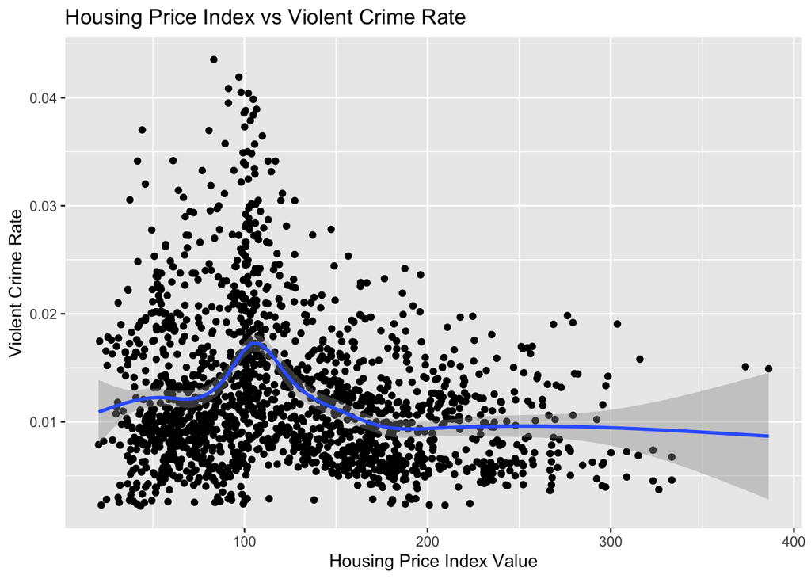

## **Plot Two**

**Purpose**:

This plot displays assaults, homicides, rapes, and robberies as a percentage out of the total number of violent crimes for areas with a Housing Price Index of 110 or lower. We thought that displaying it in the form of a stacked bar chart with a key was best for displaying multiple variables that make up a whole.

**Insights**:

Looking at this plot, we can see that assaults and robberies make up the vast majority of total violent crimes for lower HPI values. Meanwhile, rapes and homicides make up significantly less of the total violent crimes. We were a little shocked by how small a proportion that homicides make out of the total proportion. So this visualization makes it pretty clear what types of violent crimes occur the most often in low-income areas.

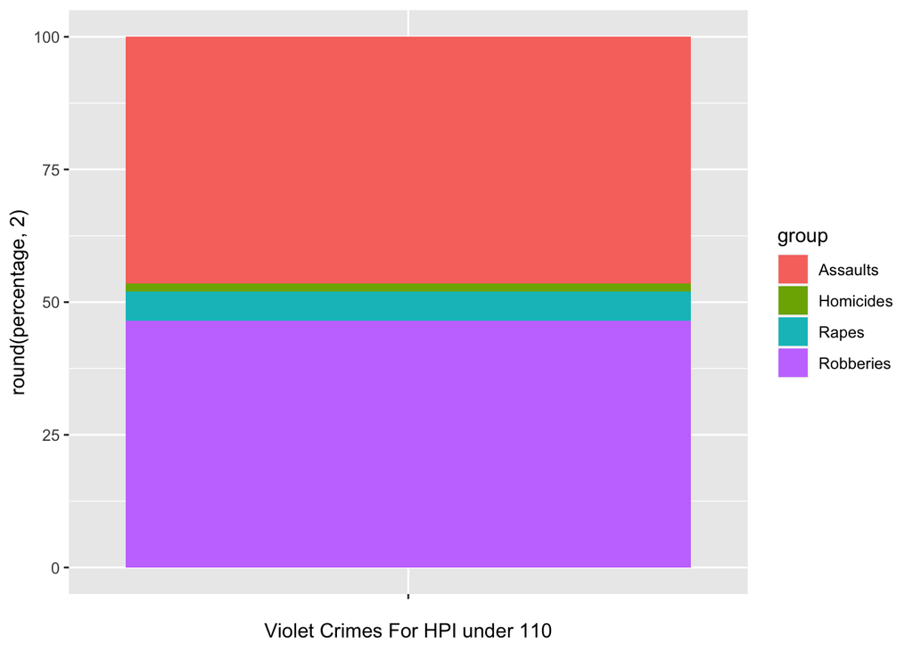

## **Plot Three**

**Purpose**:

The purpose of this plot is to answer the question regarding the difference between crime rates in low income and high income areas. The box plots are included because they delineates the spread of the data (percentage of crime) across each of the 4 categories: high, low, medium, and N/A.

**Insights**:

There are no outlier in the high category, and it has an IQR of 0.74. There are several outliers in the low category, and it has an IQR of 0.94, indicating it has a relatively high spread from the mean as opposed to other categories. There are some outliers in the medium category,and it has an IQR of 0.63. Overall, the box plots show that low income areas have the highest percentage of crime, and the data extend beyond the whiskers of the plot (meaning that there are outliers). It’s a fair assumption to make that low income areas have a higher percentage of crime as opposed to higher income areas.

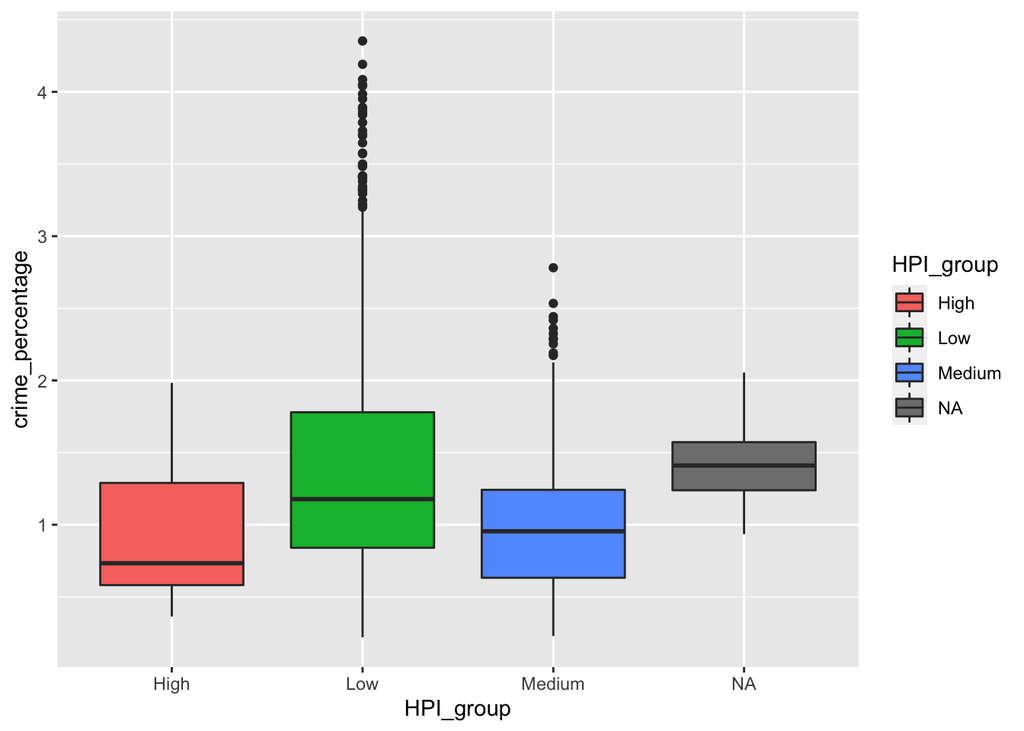

## **Plot Four**

**Purpose**:

We included this set of charts to compare how violent crime numbers across the US have changed from 1975 to 2015 and how this compares between high and low income groups. We decided that splitting this into two graphs would best display this data comparison.

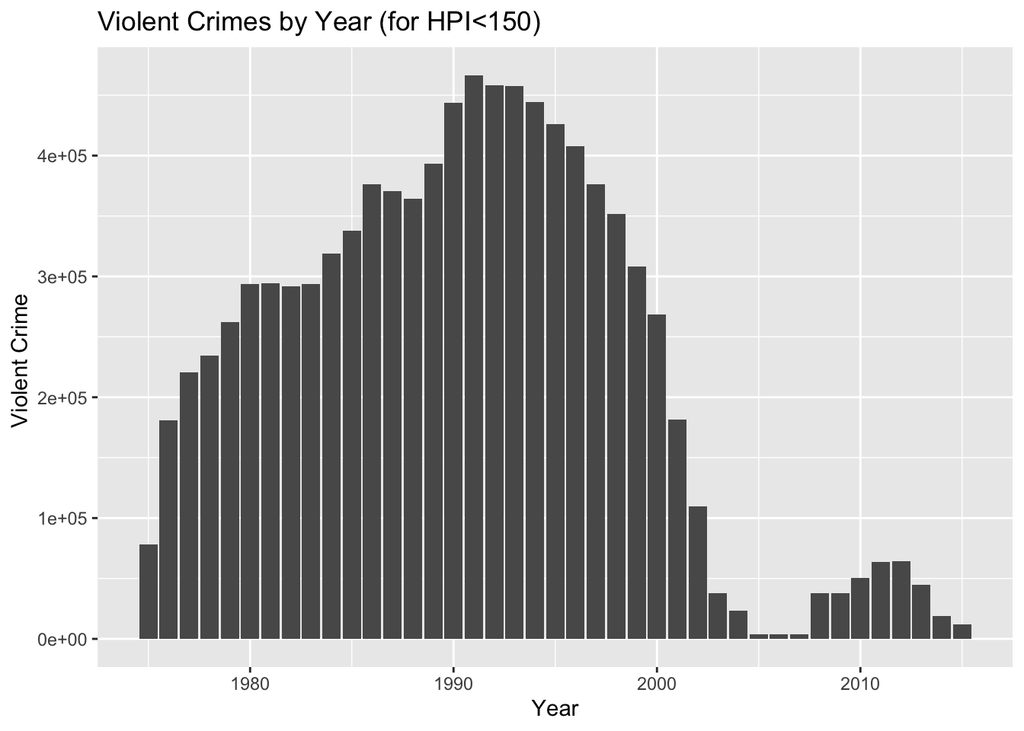

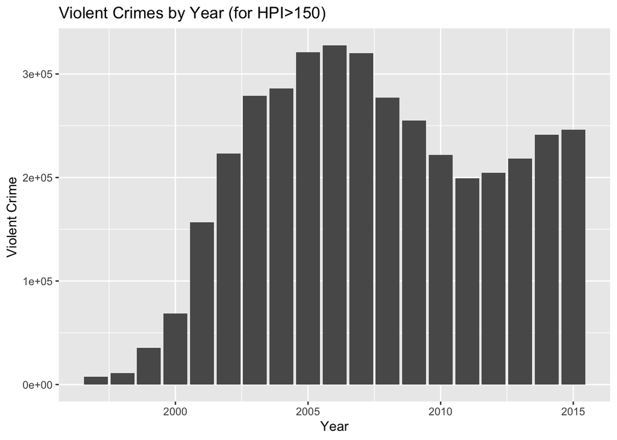